# Kasvajaviirused

Onkobioloogia

Taavi Päll

—.segue .dark .nobackground ## Tuumor-onkoviiruste avastamine

— &twocol ## Lindude leukeemia viraalne ülekanne

*** =left - 1908 aastal näitasid Taani teadlased **Vilhelm Ellerman** (1871-1924) ja **Oluf Bang** (1881-1937) et **lindude leukeemia** (*avian viral leukemia*) kandub viraalsel teel üle.

[figure not shown]

## Rous pälvis selle töö eest 1966 aastal Nobeli preemia

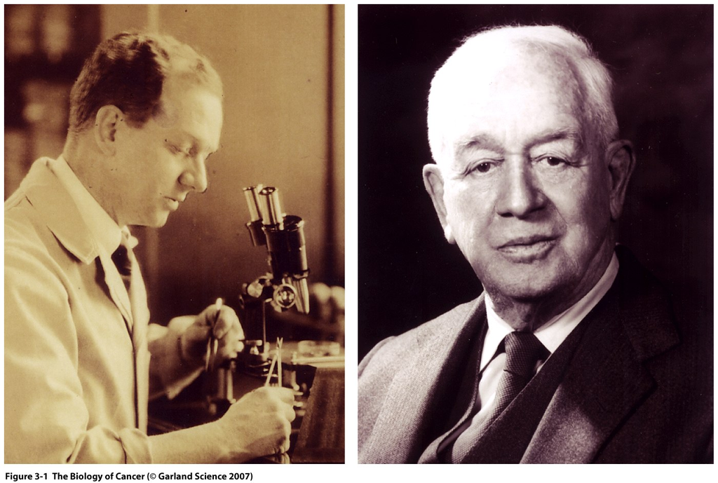

rous

## Seitse viirust

- Praegusel ajal hinnatakse, et viirused vastutavad 10-15% vähijuhtumite eest maailmas.
- **Inimestel on leitud seitsmel viirusel seos vähi tekkega.**

[figure not shown]

xkcd

## Epstein-Barri viirus (EBV)

- EBV partiklid avastati elektronmikroskoopia teel nn. **Aafrika Burkitti lümfoomi** patsientidel.
- EBV on laialt levinud ekvatoriaal Aafrikas ja Paapua Uus-Guineas.
  - Ainult 2.3% lümfoomidest on nn. Burkitti lümfoomid.
  - ~100% patsientidest nakatunud.
  - võib kaasneda malaariast või kollapalavikust tingitud immuun-puudulikkusega.
- **Sporaadiline Burkitti lümfoom** esineb arenenud maades.
  - EBV negatiivne, kuid sisaldab iseloomulikke MYC-i translokatsioone.

[figure not shown]

EBV

## HPV ja emakakaelavähk

- 1980-ndatel oli teada, et inimese papilloomiviirused põhjustavad kondüloomide (*genital warts*) teket.
- Selle põhal oletas Harald zur Hausen, et HPV võib olla seotud ka emakakaela vähi tekkega.
- Oma hüpoteesi kontrollimiseks **hübridiseeris ta papilloomiviiruse DNA emakakaelavähi DNA-le.**

[figure not shown]

HPV

## Viirused põhjustavad kasvajaid mitut moodi

Mehhanismid langevad kahte laia kategooriasse.

- **otsene mehhanism: insertsiooniline mutagenees**, onkviirused nakatavad normaalseid rakke ja integreeruvad genoomi põhjustades muutunud lokaalset geeniekspressiooni. Kui rakud koguvad veel lisamutatsioone või leiab aset immuunsüsteemi nõrgenemine, siis võivad sellised rakud viia vähi tekkeni.
- **kaudne mehhanism**, viirusinfektsioon põhjustab põletikku. Krooniline põletik tõstab vähitekke riski selles koes.

— bg:lavender ## src paradigma

Põhinedes RSV võimel mõni päev peale nakatamist rakke transformeerida, töötati 1958 Temini a Rubini poolt välja nn *focus assay*

- Fookuste hulk oli otseses seoses rakkudele lisatud RSV hulgaga, seega oli RSV täiesti piisav peremeesraku transformeerimiseks.

## Paljunemine ja raku transformeerimine on viirusel eraldi funktsioonid

- **raku fenotüüp on viiruse genoomi kontrolli all**, on olemas RSV mutandid, mis põhjustavad transformeerimisel rakkudel pikenenud fenotüübi;
- **viiruse paljunemine pole raku transformatsiooniks vajalik**, replikatsiooni-defektne mutant transformeeris rakke ilma viirust tootmata;
- **tekivad spontaansed mutandid mis replitseeruvad kuid enam ei transformeeri**, enamus RSV liine on mitte-defektsed (neil on genoomis olemas kõik viiruse replikatsiooniks vajalikud geenid ja onkogeen).

—- bg:lavender ## RSV geenide aktiivsus on vajalik transformatsiooniks

- RSV-indutseeritud transformatsioon kandub järglasrakkudele edasi.
- Kas tegemist on nn. *hit and run* mehhanismiga või on viiruse aktiivsus transformatsiooniks permanentselt vajalik
  - *hit and run*: transformeerunud fenotüüp kandub edasi juba viirusest sõltumatult.
- Viirusgeenide vajalikkus selgus 1970 kui avaldati *Nature* artikkel kus kirjeldati temperatuuritundliku (*ts*) RSV mutandiga tehtud katseid:
  - transformatsioon oli temperatuuritundlik, kuid viiruse replikatsioon mitte.

— bg:lavender ## ALV/RSV virion

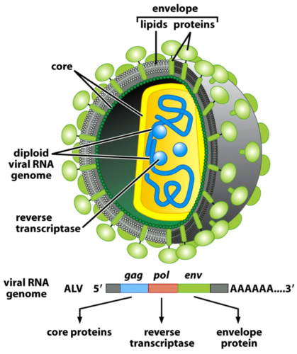

rsv

—- bg:lavender ## Metsik tüüpi RSV vs. transformatsioonidefektne (td)

td RSV genoom on väiksem

[figure not shown]

src

— bg:lavender ## Lihtsa retroviiruse elutsükkel

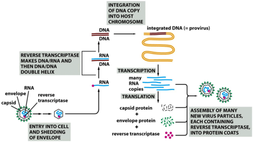

rsvlife

— &twocol bg:lavender ## RSV src pärineb raku genoomist

***=left Kasutades ära 1970 aastal RSV-st avastatud RNA sõltuvat DNA polümeraasi (pöördtranskriptaas) näidati, et selles viiruses olev transformeeriv src RNA järestus on pärit linnu genoomist.

*The Nobel Prize in Physiology or Medicine 1975 was awarded jointly to David Baltimore, Renato Dulbecco and Howard Martin Temin “for their discoveries concerning the interaction between tumour viruses and the genetic material of the cell”.*

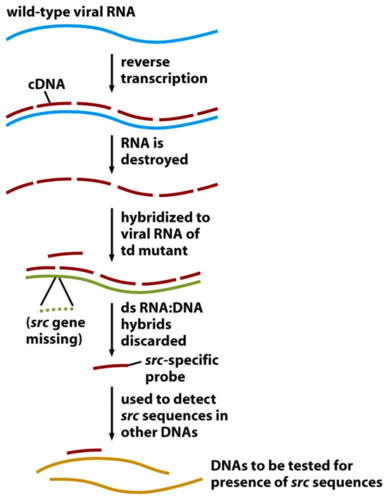

csrc

# Retroviiruste onkovalkude funktsionaalsed klassid

| Klass | Näide | Viirus |
| --- | --- | --- |
| kasvufaktor | Sis (PDGFB) | ahvi sarkoomiviirus |
| retseptor TK | ErbB (EGFR) | linnu erütroblastoosi viirus |
| hormoonretseptor | ErbA (THRA) | linnu erütroblastoosi viirus |
| G valk | Ha-ras, GTPase | Harvey sarkoomiviirus |
| Ki-ras, GTPase | Kirsten sarkoomiviirus |  |
| adaptorvalk | Crk, modulaarne signaali link CT10 | linnu sarkoomiviirus |
| mitte-retseptor TK | Src, tsütoplasma kinaas | Rousi sarkoomiviirus |
| Abl, tsütoplasma kinaas | Abelsoni hiire leukemia virus |  |
| seriin/treoniin kinaas | Akt, tsütoplasma kinaas | Akt8 hiire thymoma virus |
| Mos, tsütoplasma kinaas | Moloney hiire sarkoomiviirus |  |
| transkriptsiooni regulaator | Jun, AP1 TF kompleks | linnu sarkoomiviirus 17 |
| Fos, AP1 TF kompleks | Finkel–Biskis–Jinkins hiire sarkoomiviirus |  |
| Myc, transkriptsioonifaktor | linnu müelotsütomatoosi viirus MC29 |  |
| lipiidikinaas | Pi3k | linnu sarkoomiviirus 16 |

## Altered immune response in cervical carcinomas

- Mutations in the HLA-B, HLA-A and in the β2-microglobulin (B2M) genes.
- All mutations in these three genes were within the antigen-presenting domains of each respective protein.
- Pathway analyses also revealed that the most significantly mutated gene set in squamous cell carcinomas involves immune response genes in the interferon-γ signalling pathway, including mutations in IFNG and JAK2.
- Together, these data highlight the significance of the synergy between HPV infection and an altered immune response in squamous cell carcinomas of the cervix.

— &twocol ## SV40 kasutab samu mehhanisme mis toimivad spontaansetes kasvajates

- The co-occurrence of PPP2R1A and TP53 mutations mirrors the dual mechanism of transformation by the SV40 oncovirus.
- **Small T antigen binds PPP2R1A** to disrupt association with PP2A regulatory subunits
- and **large T antigen mediates TP53 inactivation**.

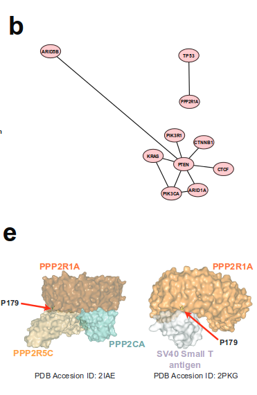

sv40T

— &twocol ## Comprehensive molecular characterization of gastric adenocarcinoma

- EBV is found within malignant epithelial cells in 9% of gastric cancers.
- Amplification of 9p locus containing JAK2, CD274 and PDCD1LG2 was enriched in the EBV subgroup (15% of tumours).
  - JAK2 encodes a receptor tyrosine kinase and potential therapeutic target.
  - CD274 and PDCD1LG2 encode PD-L1 and PD-L2, immunosuppressant proteins.

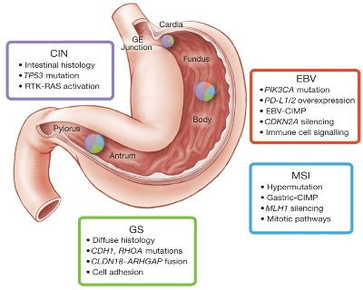

gastric

## Viited

- Why do viruses cause cancer? Highlights of the first century of human tumour virology Patrick S. Moore & Yuan Chang Nature Reviews Cancer 10, 878-889 (December 2010) doi:10.1038/nrc2961
- Retroviral oncogenes: a historical primer Peter K. Vogt Nature Reviews Cancer 12, 639-648 (September 2012) doi:10.1038/nrc3320
- The Biology of Cancer Robert A. Weinberg Garland Science (2007) ISBN: 9780815340782
- Landscape of genomic alterations in cervical carcinomas Nature 506, 371–375 (20 February 2014) doi:10.1038/nature12881
- Comprehensive molecular characterization of gastric adenocarcinoma The Cancer Genome Atlas Research Network Nature 513, 202–209 (11 September 2014) doi:10.1038/nature13480

## Lingid loengutele

- [Sissejuhatav loeng](http://tpall.github.io/sissejuhatus)
- [Vähitüübid](http://tpall.github.io/Vahityybid)
- Onkoviirused
- Onkogeenid
- Retseptorid
- Signaalirajad
- [Tuumorsupressorgeenid](http://tpall.github.io/Tuumorsupressorid)
- [Rakutsüklikontroll](http://tpall.github.io/Rakutsyklikontroll)

- [p53 ja apoptoos](http://tpall.github.io/p53-ja-apoptoos)
- Immortalisatsioon
- Tumorigenees
- Genoomiterviklikkus
- Mikrokeskkond
- [Metastaasid](http://tpall.github.io/Metastaas)
- Immuunsus
- Vahiravim